# Reading MAIAC data

This notebook documents the process and challenges of loading MAIAC data

```r
library(PWFSLSmoke)
library(PWFSLSmokeModeling)
setSpatialDataDir(spatialDataDir)
loadSpatialData("USCensusStates")
source("../R/maiac_convertGridToRaster.R")
```

```r
file <- ncdf4::nc_open(maiacFilePath)
latitude <- ncdf4::ncvar_get(file, 'grid1km_latitude')
longitude <- ncdf4::ncvar_get(file, 'grid1km_longitude')
aot <- ncdf4::ncvar_get(file, 'Optical_Depth_055')
```

The MAIAC file is gridded data. The best way to represent it in R would probably be as a Raster object (using the `raster` package). To do that, we would have to figure out the appropriate projection to assign. This metadata (an exerpt of the lengthy output from `print(file)`) may come in handy:

```
GROUP=GRID_1
        GridName="grid1km"
        XDim=1200
        YDim=1200
        UpperLeftPointMtrs=(-2800000.000000,2400000.000000)
        LowerRightMtrs=(-1600000.000000,1200000.000000)
        Projection=GCTP_ALBERS
        ProjParams=(0,0,20000000,60000000,-96000000,23000000,0,0,0,0,0,0,0)
        SphereCode=12
        GridOrigin=HDFE_GD_UL
        GROUP=Dimension
        END_GROUP=Dimension
```

NASA has [some information online](https://modis-land.gsfc.nasa.gov/MODLAND_grid.html) about the projection it uses. It turns out that the projection is sinusoidal. More specifications and the proj4 parameters can be found [here](http://spatialreference.org/ref/sr-org/modis-sinusoidal/). How convenient!

Also, when assigning values, if we assign a vector, and values are assigned starting from the upper left, and then left to right and top to bottom.

So, based on the information in the metadata and projection documentation, this is what I expect the raster should look like (trying with transposed values because I’m not sure which way is correct…):

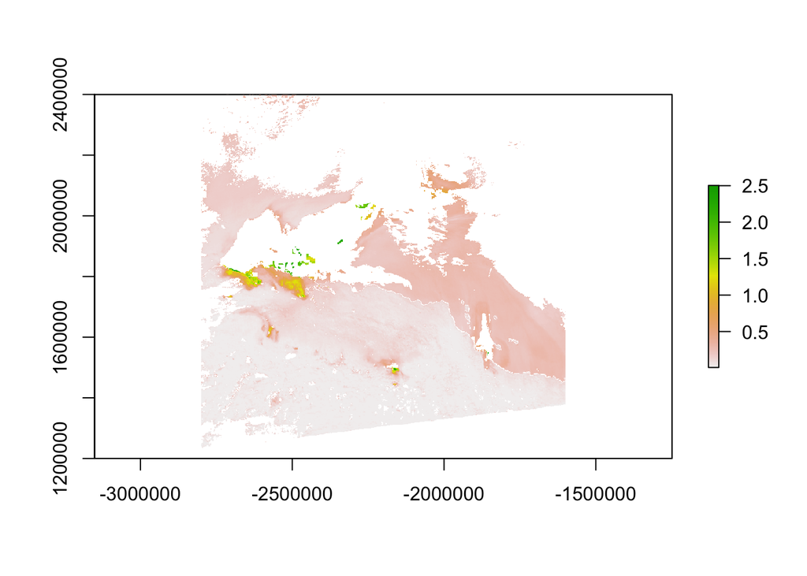

```r
aot_raster <- raster::raster(nrows = 1200, ncols = 1200,
                             xmn = -2800000.000000, xmx = -1600000.000000,
                             ymn = 1200000.000000, ymx = 2400000.000000,
                             crs = CRS("+proj=sinu +lon_0=0 +x_0=0 +y_0=0 +a=6371007.181 +b=6371007.181 +units=m +no_defs "),
                             vals = aot)
plot(aot_raster)
```

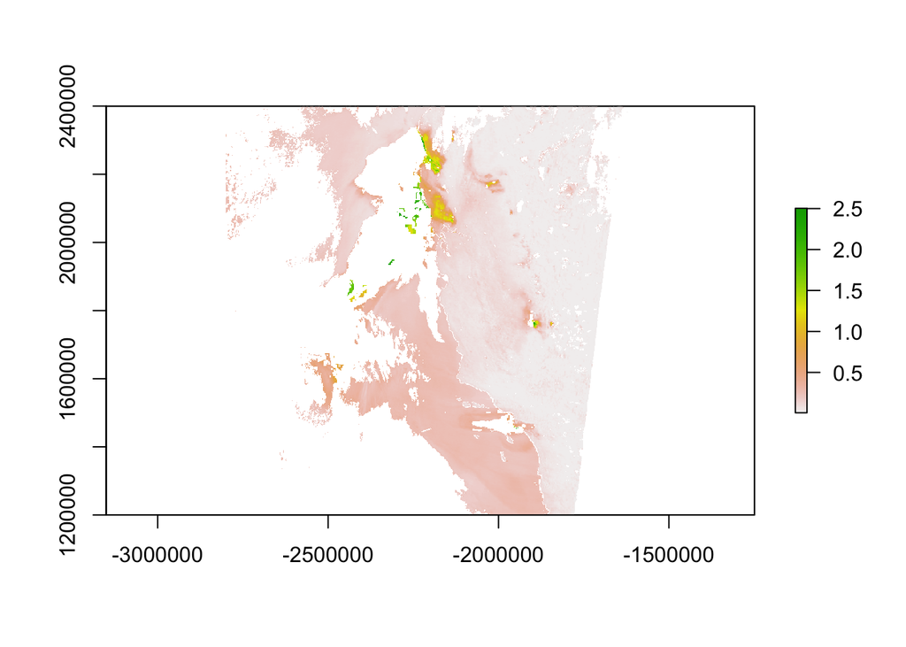

```r
aot_raster_transposed <- raster::raster(nrows = 1200, ncols = 1200,
                             xmn = -2800000.000000, xmx = -1600000.000000,
                             ymn = 1200000.000000, ymx = 2400000.000000,
                             crs = CRS("+proj=sinu +lon_0=0 +x_0=0 +y_0=0 +a=6371007.181 +b=6371007.181 +units=m +no_defs "),
                             vals = t(aot))
plot(aot_raster_transposed)
```

In the transposed version you can kind of follow what might be the California coastline in the white border. I’m not sure if it makes sense that there would be generally higher values over water than land though.

Let’s try transforming it to a more normal crs and plotting some state borders over the top.

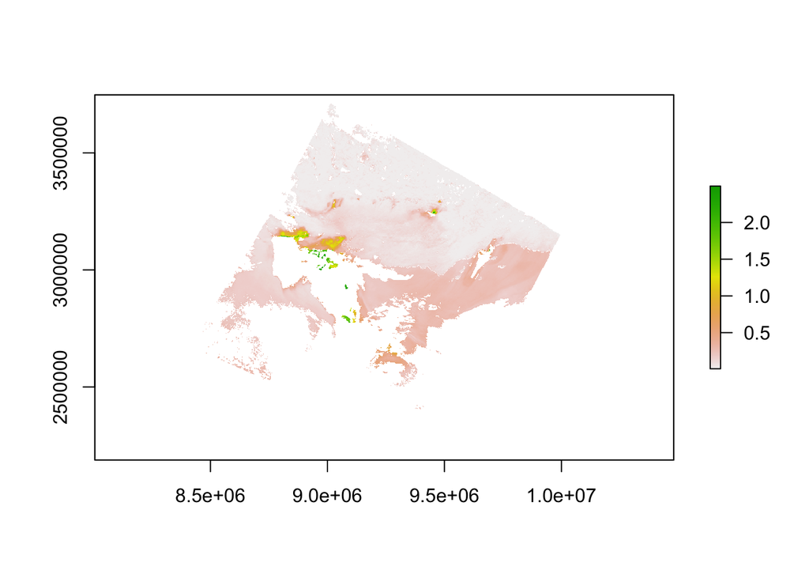

```r
aot_raster_latlong <- raster::projectRaster(aot_raster_transposed, crs = CRS("+init=epsg:3310"))
plot(aot_raster_latlong)
```

This is not the expected output. The latitude and longitude values are obviously incorrect for California, and the shape didn’t change to something more recognizable. Obviously there was some mistake in the extent or projection coordinates. Let’s try something different.

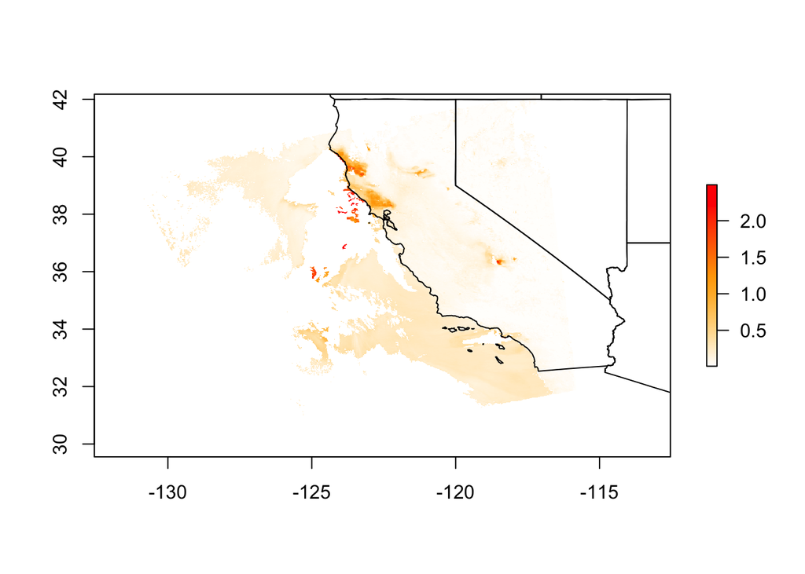

```r
aot_raster_latlong <- raster::raster(nrows = 1200, ncols = 1200,
                             xmn = min(longitude), xmx=max(longitude),
                             ymn = min(latitude), ymx=max(latitude),
                             crs = CRS("+init=epsg:3310"))
mc_raster <- raster::rasterize(x = data_frame(as.numeric(longitude), latitude=as.numeric(latitude)), y = aot_raster_latlong, field = as.numeric(aot), fun = mean, na.rm=TRUE)
plot(mc_raster, col = colorRampPalette(c("white", "orange", "red"))(255))
plot(USCensusStates, add = TRUE)
```

it is pretty succesful!

Let’s try cropping to the extent we want and plot next to some model and monitoring data.

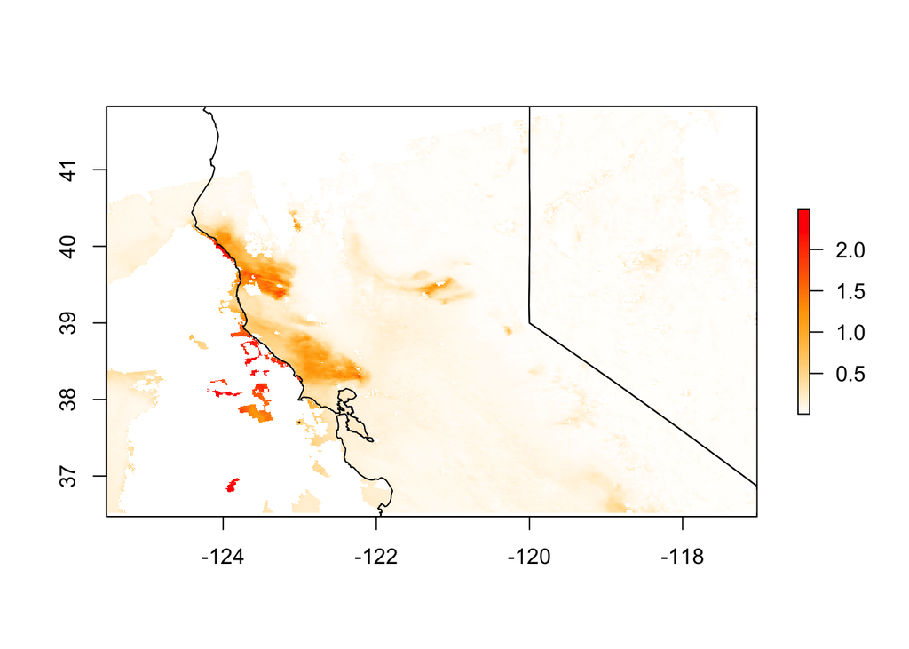

```r
fires_maiac <- raster::crop(mc_raster, raster::extent(-125.52, -117.03, 36.52, 41.78))
plot(fires_maiac, col = colorRampPalette(c("white", "orange", "red"))(255))
plot(USCensusStates, add = TRUE)
```

Load Monitor data for 10/10, using the snapshot of hour 21 (?)

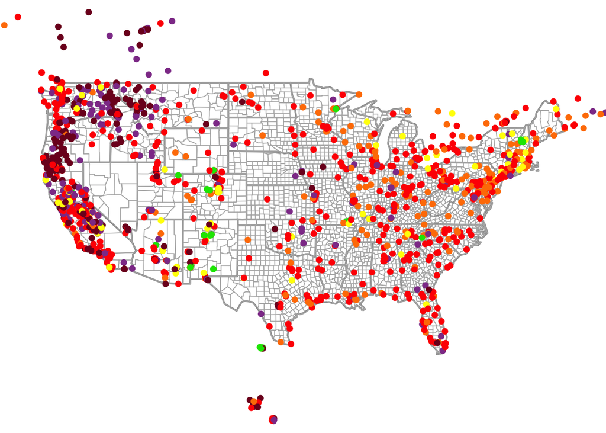

```r
airnow <- airnow_load(2017)
wrcc <- wrcc_load(2017)
airsis <- airsis_load(2017)
ws_monitor <- monitor_combine(list(airnow, wrcc, airsis))
monitorMap(ws_monitor)
```

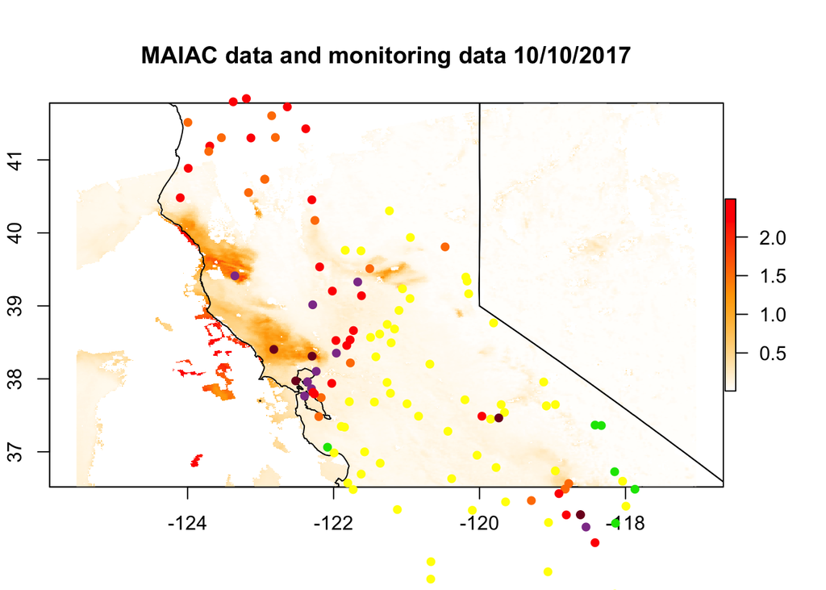

```r
fire_monitors <- monitor_subset(ws_monitor, stateCodes = "CA", tlim = c(2017101000, 2017101023))
plot(fires_maiac, col = colorRampPalette(c("white", "orange", "red"))(255), main = "MAIAC data and monitoring data 10/10/2017")
plot(USCensusStates, add = TRUE)
monitorMap(fire_monitors, add = TRUE)
```

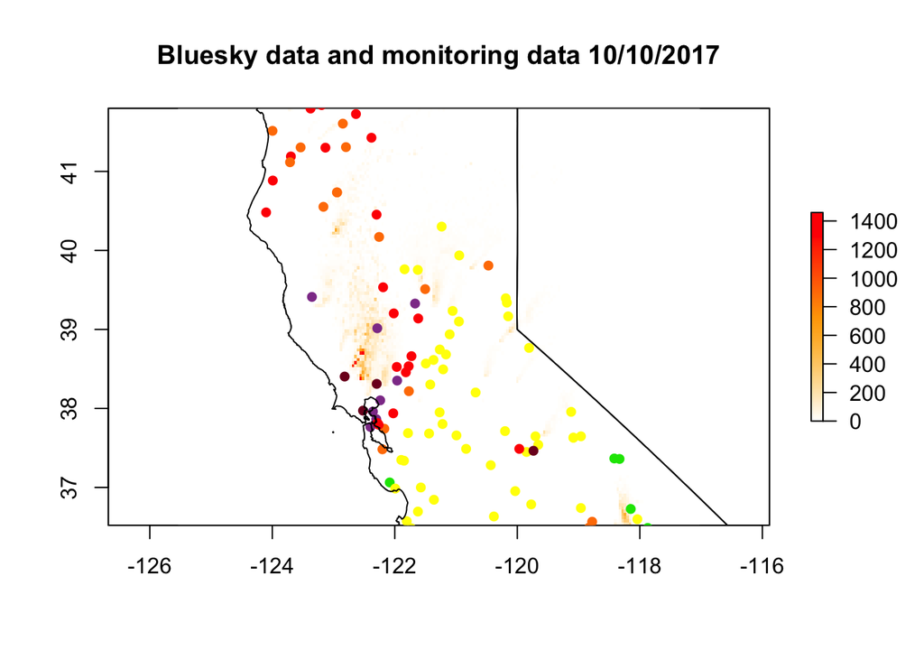

```r
bs <- bluesky_load(model = 'NAM-3km', modelRun = 2017101000, file = "/Users/helen/Data/Bluesky/NAM-3km_2017101012.nc")
fire_bs_grid <- grid_subset(bs, xlim = c(-125.52, -117.03), ylim = c(36.52, 41.78))
fire_bs <- convertGridToRaster(fire_bs_grid)
plot(fire_bs[[9]], col = colorRampPalette(c("white", "orange", "red"))(255), main = "Bluesky data and monitoring data 10/10/2017")
monitorMap(fire_monitors, add = TRUE)
plot(USCensusStates, add = TRUE)
```